# Replication of Savg Enhanced Memory: The Benefits of Saving on the Learng and Remembering of New Information” Study 3 by Storm & Stone (2015, Psychological Science)

Marty Keil (mkeil@stanford.edu)

Original Experiment is [here](https://web.stanford.edu/~mkeil/MemoryProject/mkeilProject/experiment/Saving1.html).

## Introduction

This study examines the effect of saving a document on future learning and memory. The study concludes that when a person has the opportunity to save a file before studying another file, they retain more information from this second studying session because interference is lower. The study also finds that this interference depends on the amount of information that is studied in the first file. In this replication study we expect to see increases in word recall for a second file when participants can save the first file studied or when the file has less information to be learned.

## Methods

### Power Analysis

In this study the authors conducted a 2x2 mixed-design ANOVA on the recall of File B and found a significant interaction between the word condition and save condition, F(1, 46) = 7.89, MSE = 0.01, p = .007, η2 = .15. Using this information I conducted a post-hoc power analysis for an estimated effect size of η2 = .15. This results in a power of 82% and a proposed N of 48.

### Planned Sample

48 person native English speakers from North America.

### Materials

> 16 PDF files were created, each containing a single list of 8 common nouns (four to seven letters long). Two files were randomly selected to be used for each of eight trials. One of the files associated with each trial was designated as File A, whereas the other was designated as File B. The files were then named with a trial number and corresponding letter (1A, 1B, 2A, 2B, etc.)

**Modification**: These PDF files will be placed in an online repository, to be accessed during the experiment.

### Procedure

> The experiment began with participants watching the experimenter create a folder on the desktop. The folder was named with the date (e.g., 5-4-2014), and participants were told that they would be able to use the folder during the experiment. Participants were then alerted to the flash drive connected to the computer and instructed to open it to view the files inside. The files were said to exist only on the flash drive, not on the computer.

**Modification**: This folder will already exist online. For each trial, two pdf files(A and B) will appear. File A and B will pop-up based on timers.

> Participants were told that the experiment would consist of six trials, each involving the study and testing of the contents of two PDFs. For example, on the first trial, participants studied and were tested on the contents of Files 1A and 1B. They were told that they would always study File A first, but that before being tested on it, they would study and be tested on File B. Half of the trials were save trials, and the other half were no-save trials. Counterbalancing ensured that each file served equally often in the save and no-save conditions. On save trials, participants saved File A before studying and being tested on File B. On no-save trials, participants simply exited File A without saving before studying and being tested on File B. Participants were told that saving File A would ensure that they would be able to restudy it prior to test, which they were indeed allowed to do.

> On each trial, participants studied File A unaware of whether they would be instructed to save it. After 15 s of study, participants were told to either save or not save the file into the designated folder. If instructed to save the file, participants navigated to the “Save a copy” option on the file menu and then saved the file into their folder. If instructed to not save the file, participants simply exited the file by clicking the “X” on the top-right corner of the PDF.

**Modification**: A pop-up will appear that will allow participants to save File A and they will see it remain on the website if they are in the save condition. Participants in the no-save condition will also be given a pop-up option asking them to delete the file, and see File A gone from the website after the initial studying period

> Immediately following, participants were asked to open and study the corresponding File B for 15 s. After File B was closed, there was a short 20-s delay during which participants counted backwards by 3s from a random 3-digit number between 200 and 999.

**Modification**: Instead of counting backwards by 3s, participants write these numbers online, still starting from a random 3-digit number

> Participants were then given 20 s to recall out loud the words from File B.

**Modification**: Participants will write down recalled words.

> Finally, participants were given either 20 s to recall the words from File A (no-save trials) or were instructed to open their designated folder and restudy File A for 15 s before being tested on it (save trials). After the conclusion of each trial, participants were given an unrelated distractor task (i.e., the game Tetris for 1 min) before beginning the next trial.

> At the outset of the experiment, participants were given both a save trial and a no-save trial so they could experience the reliability of the saving process, then six experimental trials consisting of three save trials and three no-save trials, presented in a semi-random interleaved order. Participants were randomly assigned to either the eight-word condition, in which File A consisted of eight words, or the two-word condition, in which File A consisted of only two words. The two-word lists were created by randomly selecting two of the words from the corresponding eight-word lists. The two conditions were otherwise identical.

### Analysis Plan

**Data Cleaning** The data for each participant will go from wide format to tidy format. Each row will be a separate subject trial, and include the participant condition(2 or 8 word), save type condition(save vs. no-save), recall score for file A, and recall score for file B.

**Data Exclusion** Any subject’s data in which all trials are not completed will be removed from the data set. Subject’s will be excluded if they perform two standard deviations below or above mean recall B score. This may be a sign of cheating, such as writing the words down or taking a screenshot while studying. Data will also be excluded if subjects mean digit recall is below two standard deviations of the overall mean. These results would show evidence that the subject is not paying attention to the task and could skew results. Data from trials 1 and 2 will be excluded for each subject, following the original experiment’s exclusion protocol. Finally, if a subject does not follow the correct save instructions for any trial their data will be throw out from the final analysis.

**Recall Performance for File A** We will run a pairwise t-test between save trials vs. non-save trials in word recall. This analysis will be done separately for two-word and eight-word conditions.

**Recall Performance for File B** 2 x 2 Mixed Design ANOVA will be run on save vs. no save and two vs. eight word conditions with recall score as the dependent variable. We will run this as an interaction model and expect to see a significant word condition by save condition interaction term. We will also run a pairwise t-test between save trials vs. non-save trials in word recall. This analysis will be done separately for two-word and eight-word conditions.

### Differences from Original Study

**Sample differences** The sample is no longer college undergraduates, but instead will consist of native english speakers from North America ages 18 and above.

**Setting differences** The setting will be implemented Online using Mechanical Turk instead of in-person. Participants will be using their own computer and accessing materials through an online site, instead of an external zip drive and destop display. This may change how participants react to saving and not saving a file, since this process may be viewed differently online as compared to offline files.

**Procedure differences** Participants will write down words recalled instead of verbally responding. This difference could lead to lower recall scores overall, since typing may slow down some participants. Students will complete subtraction problems as a distractor instead of counting backwards from 3 aloud.

## Results

### Data Preparation

#### Load Relevant Libraries and Functions

```r
library(ggplot2)
library(tidyr)
library(dplyr)
library(lme4)
library(rjson)
library(effsize)
library(compute.es)
library(grid)
library(png)

sem <- function(x) {sd(x, na.rm=TRUE) / sqrt(length(x))}
ci95 <- function(x) {sem(x) * 1.96}
```

#### Import Data Through JSON File to Dataframe

```r
path <- "~/Documents/Psych254/MturkFinal/"
files <- dir(paste0(path,"production-results/"),
             pattern = "*.json")
d.raw <- data.frame()
for (f in files) {
  jf <- paste0(path, "production-results/",f)
  jd <- fromJSON(paste(readLines(jf), collapse=""))
  jd$answers$data[9]
  for(i in 1:8){
    id <- data.frame(
                   workerId = jd$WorkerId,
                   trial_num = i,
                   start_num = jd$answers$data[[i]]$start_number,
                   digits = jd$answers$data[[i]]$digits,
                   word_condition = jd$answers$data[[i]]$word_condition,
                   save_choice = jd$answers$data[[i]]$save_choice,
                   save_condition = jd$answers$data[[i]]$save_condition,
                   FileB = jd$answers$data[[i]]$FileB,
                   FileA = jd$answers$data[[i]]$FileA,
                   B_Recall = jd$answers$data[[i]]$B_Recall,
                   A_Recall = jd$answers$data[[i]]$A_Recall,
                   time = jd$answers$data[[i]]$time,
                   age = jd$answers$data[[9]]$age,
                   gender = jd$answers$data[[9]]$gender,
                   homelang = jd$answers$data[[9]]$homelang,
                   race = jd$answers$data[[9]]$race
                   # comments = jd$answers$data[[9]]$comments
                   )
    d.raw <- bind_rows(d.raw, id)
  }
}
```

#### Score Digits

This code calculates the number of times the subject correctly subtracted by 3 in the distractor task.

```r
d1 <- d.raw

entered_digits = strsplit(d1$digits, "[\n]")

for(i in seq(from=1, to=nrow(d1), by=1)){
  correct_digit = d1$start_num[i]
  digitScore = 0
  for(digit in entered_digits[[i]]){
    correct_digit = correct_digit -3
    if (digit == correct_digit){
      digitScore = digitScore + 1
    }
    correct_digit = as.numeric(digit)
  }
  digitScore
  d1$DigitScore[i] = digitScore
}
```

#### Score FileRecall

This piece of code calculates the number of correct words recalled from File A and File B for each trial. The user input is compared to the actual list of words in the file, and for each match the score increases by 1. The code also gives participants credit for accidentally recalling the singular version of a plural word by translating it from singular to plural before scoring (examples: eggs, bikes, planes, and jeans).

```r
#FileA
FileA_split = strsplit(d1$FileA, "[,]")
FileA_recall_split = strsplit(d1$A_Recall, "[\n]")

for(i in seq(from=1, to=nrow(d1), by=1)){
  FileA_split[[i]]
  FileAScore = 0
  for(word in FileA_recall_split[[i]]){
    #adjustment for plural words
    if(word == "egg"){
      word = paste(word,"s",sep = "")
    }
    word = tolower(c(word))
    if ( word %in% FileA_split[[i]]){
      FileAScore = FileAScore + 1
    }
  }
  if (d1$word_condition[i]==8){
    d1$AScore[i] = FileAScore/8
  }
  else {
    d1$AScore[i] = FileAScore/2
  }
}

#FileB
for(i in seq(from=1, to=nrow(d1), by=1)){
  FileB_split = strsplit(d1$FileB, "[,]")
  FileB_split[[i]]
  FileB_recall_split = strsplit(d1$B_Recall, "[\n]")
  FileBScore = 0
  for(word in FileB_recall_split[[i]]){
    #adjustment for plural words
    if(word == "bike" | word == "plane" | word == "jean"){
      word = paste(word,"s",sep = "")
    }
    word = tolower(c(word))
    if ( word %in% FileB_split[[i]]){
      FileBScore = FileBScore + 1
    }
  }
  FileBScore
  d1$BScore[i] = FileBScore/8
}
```

#### Data Exclusion

Remove first two trials(training) from analysis and exemption

```r
#remove trialnum 1 and 2
d1 <- d1 %>% filter(trial_num != 1, trial_num != 2)
```

Remove anyone who did not follow save instructions correctly

```r
#rename save choice from delete
d1 <- d1 %>% mutate(save_condition = ifelse(save_condition == "nosave","delete","save"))

#remove wrong followers
included_workers <- d1 %>%
group_by(workerId)  %>%
summarise(followed_instructions = all(save_condition == save_choice)) %>%
filter(followed_instructions)
d1 <- d1 %>% filter(workerId %in% included_workers$workerId)
#7 particpants eliminated
```

Remove those 2 standard deviations below or above in word recall score and digit recall score.

```r
d1_means <- d1 %>%group_by(workerId,word_condition) %>% summarise(meanB = mean(BScore), meanA =mean(AScore), meanDigit = mean(DigitScore), meanTime = mean(time))

#filter by recallScore
sb_meanB = sd(d1_means$meanB)
top_cutoff = mean(d1_means$meanB) + (2*sb_meanB)
bottom_cutoff = mean(d1_means$meanB) - (2*sb_meanB)

#filter by digitScore
sb_digitScore = sd(d1_means$meanDigit)
digit_top_cutoff = mean(d1_means$meanDigit) + (2*sb_digitScore)
digit_bottom_cutoff = mean(d1_means$meanDigit) - (2*sb_digitScore)

d1_keep <- filter(d1_means, meanB < top_cutoff & meanB > bottom_cutoff)
d1_keep <- filter(d1_keep, meanDigit > digit_bottom_cutoff)
d1_means <- d1_keep
d1 <- filter(d1, workerId %in% d1_keep$workerId)
```

#### Plots of Data

Histogram of File B Recall Scores

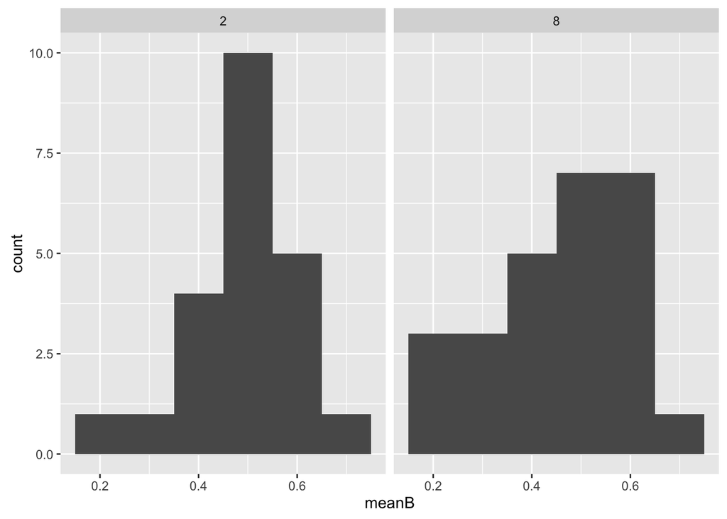

```r
qplot(meanB, data = d1_means, geom ="histogram",binwidth = .1,facets=~word_condition)
```

Histogram of File A Recall Scores

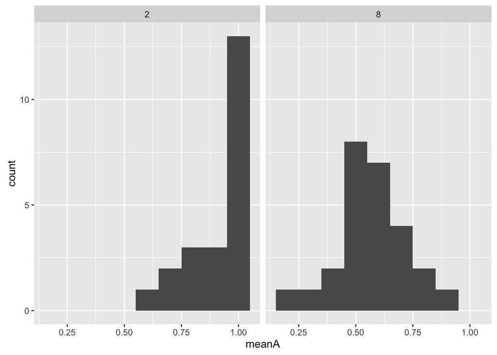

```r
qplot(meanA, data = d1_means, geom ="histogram", binwidth = .1,facets=.~word_condition)
```

Histogram of Time

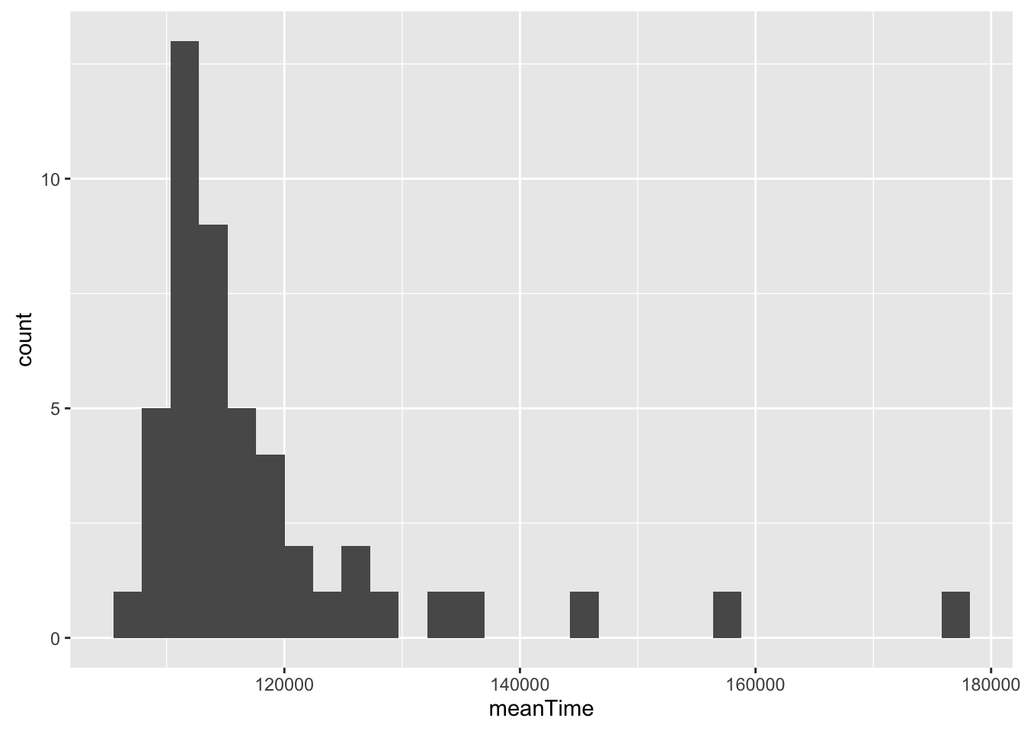

```r
qplot(meanTime, data = d1_means, geom ="histogram")
```

Histogram of Digit Recall

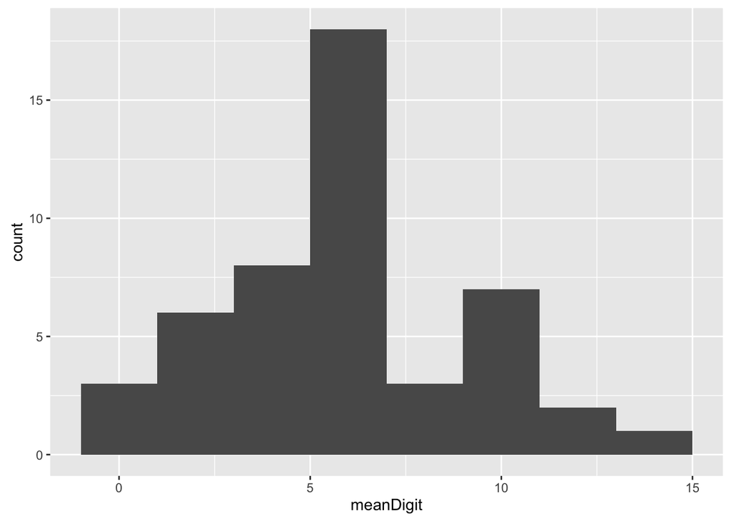

```r
qplot(meanDigit, data = d1_means, geom ="histogram", binwidth = 2)
```

#### Plot By Save vs. No-Save condition (Key Plot)

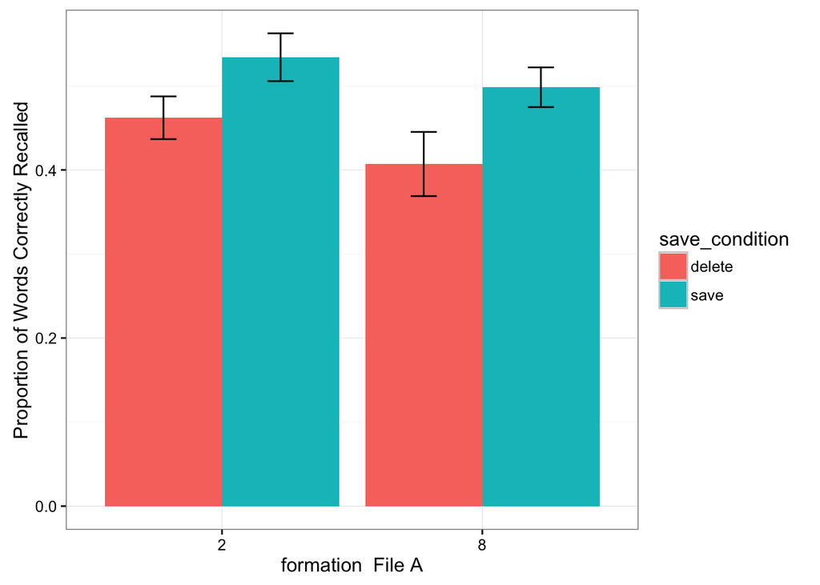

```r
d1_bar <- d1 %>%group_by(gender,race,age,workerId,word_condition,save_condition) %>% summarise(meanB = mean(BScore), meanA =mean(AScore), meanDigit = mean(DigitScore), meanTime = mean(time), seB = sem(BScore), seA = sem(AScore))

d2_bar <- d1_bar %>%group_by(word_condition,save_condition) %>% summarise(meanBacross = mean(meanB), meanA =mean(meanA), meanDigit = mean(meanDigit), meanTime = mean(meanTime), seB = sem(meanB))

d2_bar$word_condition = as.factor(d2_bar$word_condition)

#The plot of Study 3  the paper
ggplot(d2_bar,aes(x = word_condition, y = meanBacross,fill=save_condition))+
  geom_bar(position='dodge',stat='identity')+
  geom_errorbar(aes(ymin=meanBacross-seB,ymax=meanBacross+seB),
                width=.2,
                position=position_dodge(.9)) + theme_bw() + ylab("Proportion of Words Correctly Recalled") + xlab("formation  File A")
```

#### Plot from Original Paper

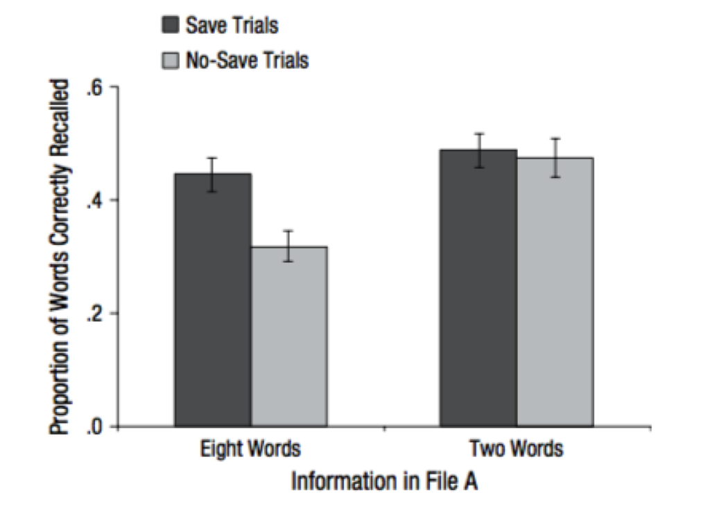

```r
img <- readPNG("~/Documents/Psych254/MemoryProject/writeup/figures/StormFigure.png")
grid.raster(img)
```

### Confirmatory Analyses

#### Confirmatory Analysis 1: Recall Performance for File A

##### Confirmatory Analysis 1.1: Eight-Word Condition File A Recall

```r
#filter data to 8-word condition and subgroups
dword8 <- d1_bar %>% filter(word_condition == 8)
dword8Save <- dword8 %>% filter(save_condition == "save")
dword8Delete <- dword8 %>% filter(save_condition == "delete")

#t-test 8-word condition
ttestA8 = t.test(meanA ~ save_condition, data = dword8)
ttestA8
```

```
##
##  Welch Two Sample t-test
##
## data:  meanA by save_condition
## t = -8.0325, df = 49.121, p-value = 1.675e-10
## alternative hypothesis: true difference in means is not equal to 0
## 95 percent confidence interval:
##  -0.5609721 -0.3364638
## sample estimates:
## mean in group delete   mean in group save
##            0.3509615            0.7996795
```

```r
#effect size for difference in conditions
cohen.d(dword8Save$meanA,dword8Delete$meanA)
```

```
##
## Cohen's d
##
## d estimate: 2.227803 (large)
## 95 percent confidence interval:
##      inf      sup
## 1.499119 2.956487
```

```r
#File A Recall Standard Error
sem(dword8Save$meanA)
```

```
## [1] 0.03676409
```

```r
sem(dword8Delete$meanA)
```

```
## [1] 0.04206052
```

The result of the 8-word File A recall for the original study was:

> In the eight-word condition, the proportion of words recalled was significantly greater on save trials (M = .80, SE = .03) than on no-save trials (M = .29, SE = .03), t(23) = 14.24, p < .001, d = 2.91, mean difference = .51 (95% CI = [.43, .58])

This replication supports the original finding of a significant main effect of save trials in File A recall for the eight-word condition, with significantly better performance on save trials (M = .80, SE = .04) compared to no-save trials (M = .35, SE = .04), t(25) = 8.03, p<.001, d = 2.23, mean difference = .45 (95% CI = [.34,.56]).

##### Confirmatory Analysis 1.2: Two-Word Condition File A Recall

```r
#filter data to 8-word condition and subgroups
dword2 <- d1_bar %>% filter(word_condition == 2)
dword2Save <- dword2 %>% filter(save_condition == "save")
dword2Delete <- dword2 %>% filter(save_condition == "delete")

#t-test 2-word condition
ttestA2 = t.test(meanA ~ save_condition, data = dword2)
ttestA2
```

```
##
##  Welch Two Sample t-test
##
## data:  meanA by save_condition
## t = -3.0601, df = 21, p-value = 0.005945
## alternative hypothesis: true difference in means is not equal to 0
## 95 percent confidence interval:
##  -0.26720873 -0.05097309
## sample estimates:
## mean in group delete   mean in group save
##            0.8409091            1.0000000
```

```r
#effect size for difference in conditions
cohen.d(dword2Save$meanA,dword2Delete$meanA)
```

```
##
## Cohen's d
##
## d estimate: 0.9226446 (large)
## 95 percent confidence interval:
##       inf       sup
## 0.2660547 1.5792345
```

```r
#standard error calculations
sem(dword2Save$meanA)
```

```
## [1] 0
```

```r
sem(dword2Delete$meanA)
```

```
## [1] 0.05198937
```

The result of the two-word File A recall for the original study was:

> A similar difference was observed in the two-word condition, with performance being perfect on save trials (M = 1.00, SE = .00) and significantly worse than perfect on no-save trials (M = .79, SE = .05), t(23) = 3.98, p = .001, d = 0.81, mean differ- ence = .21 (95% CI = [.10, .32]).

This replication also supports the original finding of a significant main effect of save trials in File A recall for the two-word condition, with perfect performance on save trials (M =1.00, SE = .00) and significantly worse recall on no-save trials (M = .84,SE = .05), t(21) = 3.06, p = .006, d = .92, mean difference = .16 (95% CI = [.05,.27]).

#### Confirmatory Analysis 2: Recall Performance for File B

###### Confirmatory Analysis 2.1: Eight-Word Condition File B Recall

```r
#t-test 8-word condition
ttestB8 = t.test(meanB ~ save_condition, data = dword8)
ttestB8
```

```
##
##  Welch Two Sample t-test
##
## data:  meanB by save_condition
## t = -2.0334, df = 41.677, p-value = 0.04841
## alternative hypothesis: true difference in means is not equal to 0
## 95 percent confidence interval:
##  -0.1820258190 -0.0006664887
## sample estimates:
## mean in group delete   mean in group save
##            0.4070513            0.4983974
```

```r
#effect size for difference in conditions
cohen.d(dword8Save$meanB,dword8Delete$meanB)
```

```
##
## Cohen's d
##
## d estimate: 0.5639585 (medium)
## 95 percent confidence interval:
##        inf        sup
## -0.0157734  1.1436905
```

The result of the 8-word File B recall for the original study was:

> participants in the eight-word condition recalled significantly more words from File B when they had saved File A than when they had not saved File A, t(23) = 4.56, p < .001, d = 0.93, mean difference = .13 (95% CI = [.07, .18]).

This data replicates the original significant result, with partipcants recalling significantly more words from file B when saving file A vs. not saving File A, t(25) = 2.03, p = .048, d = 0.56, mean difference = .09 (95% CI = [.001, .18]).

###### Confirmatory Analysis 2.2: Two-Word Condition File B Recall

```r
#t-test 2-word condition
ttestB2 = t.test(meanB ~ save_condition, data = d1_bar %>% filter(word_condition == 2))
ttestB2
```

```
##
##  Welch Two Sample t-test
##
## data:  meanB by save_condition
## t = -1.887, df = 41.477, p-value = 0.06617
## alternative hypothesis: true difference in means is not equal to 0
## 95 percent confidence interval:
##  -0.148966940  0.005027546
## sample estimates:
## mean in group delete   mean in group save
##            0.4621212            0.5340909
```

```r
#effect size for difference in conditions
cohen.d(dword2Save$meanB,dword2Delete$meanB)
```

```
##
## Cohen's d
##
## d estimate: 0.5689565 (medium)
## 95 percent confidence interval:
##         inf         sup
## -0.06690037  1.20481340
```

The result of the two-word File B recall for the original study was:

> When File A consisted of only two words, participants did not recall significantly more words from File B after they had saved File A than after they had not saved File A, t(23) = 0.40, p = .69, d = 0.08, mean difference = .01 (95% CI = [−.05, .07]).

This data shows with marginal significance that participants recall more words from file B when saving file A vs. not saving File A, t(21) = 1.89, p = .066, d = 0.57, mean difference = .07 (95% CI = [-.005, .15]).

#### Confirmatory Analysis 3: Mixed Design ANOVA for File B Performance (replication main analysis)

```r
d1$word_condition = as.factor(d1$word_condition)
aov_mixed <- aov(BScore ~ save_condition*word_condition + Error(workerId/save_condition), data=d1)
summary(aov_mixed)
```

```
##
## Error: workerId
##                Df Sum Sq Mean Sq F value Pr(>F)
## word_condition  1  0.147 0.14725   1.522  0.224
## Residuals      46  4.450 0.09675
##
## Error: workerId:save_condition
##                               Df Sum Sq Mean Sq F value   Pr(>F)
## save_condition                 1 0.4896  0.4896  15.005 0.000338 ***
## save_condition:word_condition  1 0.0067  0.0067   0.206 0.652320
## Residuals                     46 1.5010  0.0326
## ---
## Signif. codes:  0 '***' 0.001 '**' 0.01 '*' 0.05 '.' 0.1 ' ' 1
##
## Error: Within
##            Df Sum Sq Mean Sq F value Pr(>F)
## Residuals 192  7.625 0.03971
```

The result of the original study 2x2 ANOVA:

> A 2 (trial type: save vs. no save) × 2 (condition: eight word vs. two word) mixed-design ANOVA revealed a significant interaction, F(1, 46) = 7.89, MSE = 0.01, p = .007, η2 = .15

### Exploratory Analyses

#### The Influence of Demographic Factors on Performance

```r
#using ANOVA
d1$age = as.numeric(d1$age)
aov_dem = aov(BScore ~ save_condition*word_condition + gender + age + race + Error(workerId/save_condition), data=d1)
summary(aov_dem)
```

```
##
## Error: workerId
##                Df Sum Sq Mean Sq F value Pr(>F)
## word_condition  1  0.147 0.14725   1.465  0.233
## gender          1  0.110 0.11023   1.097  0.301
## age             1  0.011 0.01075   0.107  0.745
## race            3  0.208 0.06947   0.691  0.563
## Residuals      41  4.121 0.10051
##
## Error: workerId:save_condition
##                               Df Sum Sq Mean Sq F value   Pr(>F)
## save_condition                 1 0.4896  0.4896  15.005 0.000338 ***
## save_condition:word_condition  1 0.0067  0.0067   0.206 0.652320
## Residuals                     46 1.5010  0.0326
## ---
## Signif. codes:  0 '***' 0.001 '**' 0.01 '*' 0.05 '.' 0.1 ' ' 1
##
## Error: Within
##            Df Sum Sq Mean Sq F value Pr(>F)
## Residuals 192  7.625 0.03971
```

```r
#using linear model
d1_bar$age = as.numeric(d1_bar$age)
lmage = lm(meanB ~ age + race + gender, data=d1_bar)
summary(lmage)
```

```
##
## Call:
## lm(formula = meanB ~ age + race + gender, data = d1_bar)
##
## Residuals:
##      Min       1Q   Median       3Q      Max
## -0.49810 -0.07201  0.01344  0.09872  0.25893
##
## Coefficients:
##               Estimate Std. Error t value Pr(>|t|)
## (Intercept)  0.4780456  0.0724704   6.596 2.82e-09 ***
## age          0.0006975  0.0015831   0.441    0.661
## raceblack   -0.0461698  0.0759479  -0.608    0.545
## raceother    0.1920697  0.1176979   1.632    0.106
## racewhite   -0.0106409  0.0472145  -0.225    0.822
## gendermale  -0.0479980  0.0325830  -1.473    0.144
## ---
## Signif. codes:  0 '***' 0.001 '**' 0.01 '*' 0.05 '.' 0.1 ' ' 1
##
## Residual standard error: 0.1515 on 90 degrees of freedom
## Multiple R-squared:  0.06044,    Adjusted R-squared:  0.008245
## F-statistic: 1.158 on 5 and 90 DF,  p-value: 0.3361
```

#### The Effect of Trial Number on Performance

Plot by Trial Number

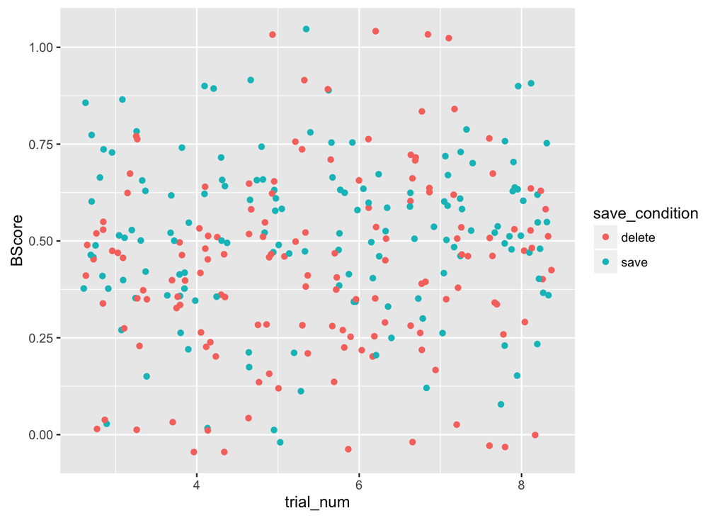

```r
ggplot(d1,aes(trial_num,BScore))+
  geom_jitter(aes(colour = save_condition))
```

There appears to be no trend for trial number.

#### The Effect of Digit Recall on Performance

Plot By Digit Recall Score

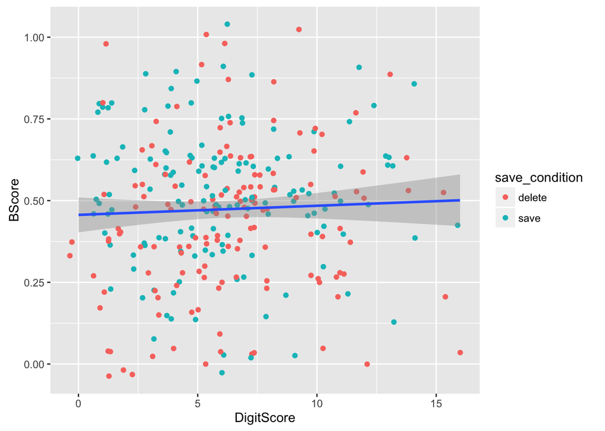

```r
ggplot(d1,aes(DigitScore,BScore))+
  geom_jitter(aes(colour = save_condition))+
  geom_smooth(method="lm")
```

There appears to be no significant relationship between digit recall and performance.

#### The Effect of File A Recall Score on File B Recall Scores for 8-word No-Save condition

Plot by File A Recall Score

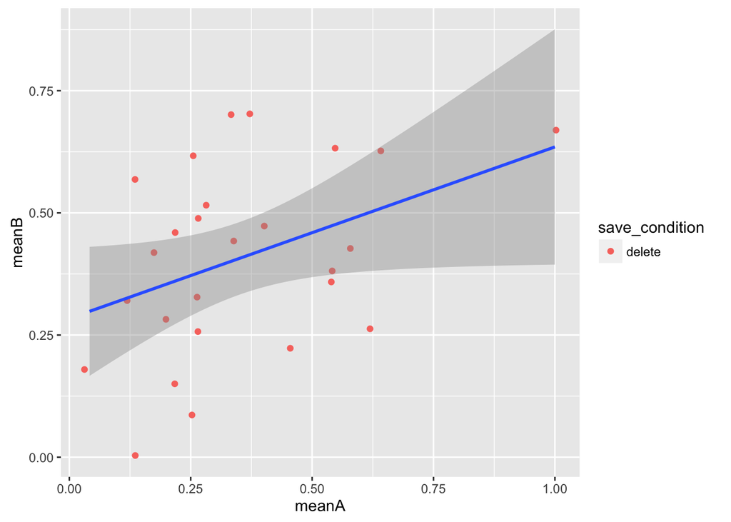

```r
d18 <- d1_bar %>% filter(word_condition == 8) %>% filter(save_condition == "delete")
ggplot(d18,aes(meanA,meanB))+
    geom_jitter(aes(colour = save_condition))+
    geom_smooth(method="lm")
```

There appears to be a positive relaitonship between File A and File B scores.

Statistical Analysis

```r
lmA <- lm(meanB~meanA, data = d18)
summary(lmA)
```

```
##
## Call:
## lm(formula = meanB ~ meanA, data = d18)
##
## Residuals:
##      Min       1Q   Median       3Q      Max
## -0.32772 -0.11596  0.01691  0.11975  0.30747
##
## Coefficients:
##             Estimate Std. Error t value Pr(>|t|)
## (Intercept)  0.28383    0.06998   4.056 0.000457 ***
## meanA        0.35108    0.17103   2.053 0.051150 .
## ---
## Signif. codes:  0 '***' 0.001 '**' 0.01 '*' 0.05 '.' 0.1 ' ' 1
##
## Residual standard error: 0.1834 on 24 degrees of freedom
## Multiple R-squared:  0.1494, Adjusted R-squared:  0.1139
## F-statistic: 4.214 on 1 and 24 DF,  p-value: 0.05115
```

## Discussion

### I.Summary of Replication Attempt

The confirmatory analyses from this study find a signficant benefit for file recall when saving a previous file instead of deleting the file. This result replicates one of the main results of Storm and Stone’s original study, in which they argue for the benefits of saving on remembering new information. Although it should be noted that the effect size for this save condition difference in the eight-word condition is smaller than the original study. The confirmatory analyses also show no significant interaction term between word condition and save condition when predicting File B recall. This result does not replicate the original experiment. We therefore conclude that the study has been partially replicated.

### II.Commentary

The MTurk sample could explain why there was a marginally significant difference in saving for the two-word condition. It may be that having to keep in mind two-words during the recall condition still provides significant proactive interference when studying file B.